# Basics and Linear Models

Michael Mayer

2022-05-11

# 1 Basics

Before heading into linear regression and the generalized linear model, we introduce some basic notation.

## 1.1 Data organization

*Structured* data is organized as one or multiple tables. Each row of a table represents an *observation*, each column $X$ a *variable* and each cell a *value*. A value in column $X$ can be viewed as a realization of the *random variable* $X$.

Examples of *unstructured* data are images, text, audio or video data. We will deal with structured data only.

Throughout this lecture, we will consider the following two data sets:

- `diamonds`: Diamonds prices along with the four “C”-variables: Carat, Color, Cut, and Clarity. Each observation/row represents a diamond.
- `dataCar`: Insurance claim data on vehicle insurance policies from 2004-2005. Some variables like `gender` describe the policy holder, others like `veh_age` the vehicle and some variables carry information on eventual claims. Each row represents a policy.

### 1.1.1 Example: diamonds

Let us have look at the first six observations of the diamonds data set.

```r
library(ggplot2)

head(diamonds)
```

| carat | cut | color | clarity | depth | table | price | x | y | z |
| --- | --- | --- | --- | --- | --- | --- | --- | --- | --- |
| 0.23 | Ideal | E | SI2 | 61.5 | 55 | 326 | 3.95 | 3.98 | 2.43 |
| 0.21 | Premium | E | SI1 | 59.8 | 61 | 326 | 3.89 | 3.84 | 2.31 |
| 0.23 | Good | E | VS1 | 56.9 | 65 | 327 | 4.05 | 4.07 | 2.31 |
| 0.29 | Premium | I | VS2 | 62.4 | 58 | 334 | 4.20 | 4.23 | 2.63 |
| 0.31 | Good | J | SI2 | 63.3 | 58 | 335 | 4.34 | 4.35 | 2.75 |
| 0.24 | Very Good | J | VVS2 | 62.8 | 57 | 336 | 3.94 | 3.96 | 2.48 |

**Comment:** The data set is neatly structured. It seems to be sorted by price.

## 1.2 Data types

We distinguish variables by their data type.

- **numerical:** The values of a numerical variable are numbers. Taking sums, means and differences makes sense. Examples: house prices, insurance claim frequencies, blood pressure.
- **categorical:** The values of a categorical variable are categories, such as house types, claim types or colors. Depending on whether categories follow a natural order, we talk of *ordered* or *unordered* categoricals. Categories can be encoded by numbers. That does not make the variable numeric though.
- **binary:** A binary variable just takes two values (male/female, yes/no, …) that can be represented by 1/0. It counts as both numeric and categorical.

Data types are important in determining suitable analysis methods.

### 1.2.1 Example: diamonds

In the `diamonds` data set, we will consider the numeric variables `price` and `carat` and the following *ordered* categoricals:

- `color` with ordered categories D < E < F < G < H < I < J,
- `cut` with ordered categories Fair < Good < Very Good < Premium < Ideal, and
- `clarity` with ordered categories I1 < SI2 < SI1 < VS2 < VS1 < VVS2 < VVS1 < IF.

There are no unordered categoricals or binary variables in this data set.

## 1.3 Descriptive analysis

Statistical modeling always starts with a descriptive analysis of the data. This typically involves a numeric and/or graphical summary of each variable and the most relevant variable pairs, e.g.,

- for numeric variables: mean, standard deviation, quartiles, minimum and maximum; boxplots, mean plots,
- for categorical variables: absolute or relative counts; bar plots,
- for binary variables: like a categorical variable or simply the mean,
- for important pairs of numeric variables: correlations; scatter plots,
- the important pairs of categorical variables: frequency tables; mosaic plots,
- for important pairs of categorical *and* numerical variables: stratified means; mean plots, boxplots.

The more time we invest in the descriptive analysis, the more we learn about the data. Additionally, we might

- identify data errors and problematic outliers (uncommonly small or large values),
- find join keys to combine multiple data sources,
- detect variables with high number of missing values,
- detect variables with no or almost no information (for instance when all values are identical),
- **learn how the data is structured** (what *is* a row? do we deal with time series? are rows grouped to clusters etc.),
- …

During or after the descriptive analysis, we usually do the *data preprocessing* for the modeling task.

### 1.3.1 Example: diamonds

Let us summarize the diamonds data set.

```r
library(ggplot2)

# Number of observations
nrow(diamonds)  # 53940
```

```
## [1] 53940
```

```r
# Univariate description
summary(diamonds[, c("price", "carat", "color", "cut", "clarity")])
```

```
##      price           carat        color            cut           clarity
##  Min.   :  326   Min.   :0.2000   D: 6775   Fair     : 1610   SI1    :13065
##  1st Qu.:  950   1st Qu.:0.4000   E: 9797   Good     : 4906   VS2    :12258
##  Median : 2401   Median :0.7000   F: 9542   Very Good:12082   SI2    : 9194
##  Mean   : 3933   Mean   :0.7979   G:11292   Premium  :13791   VS1    : 8171
##  3rd Qu.: 5324   3rd Qu.:1.0400   H: 8304   Ideal    :21551   VVS2   : 5066
##  Max.   :18823   Max.   :5.0100   I: 5422                     VVS1   : 3655
##                                   J: 2808                     (Other): 2531
```

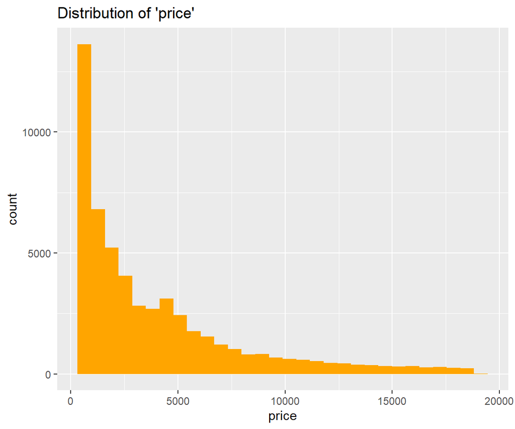

```r
ggplot(diamonds, aes(x = price)) +
  geom_histogram(fill = "orange") +
  ggtitle("Distribution of 'price'")
```

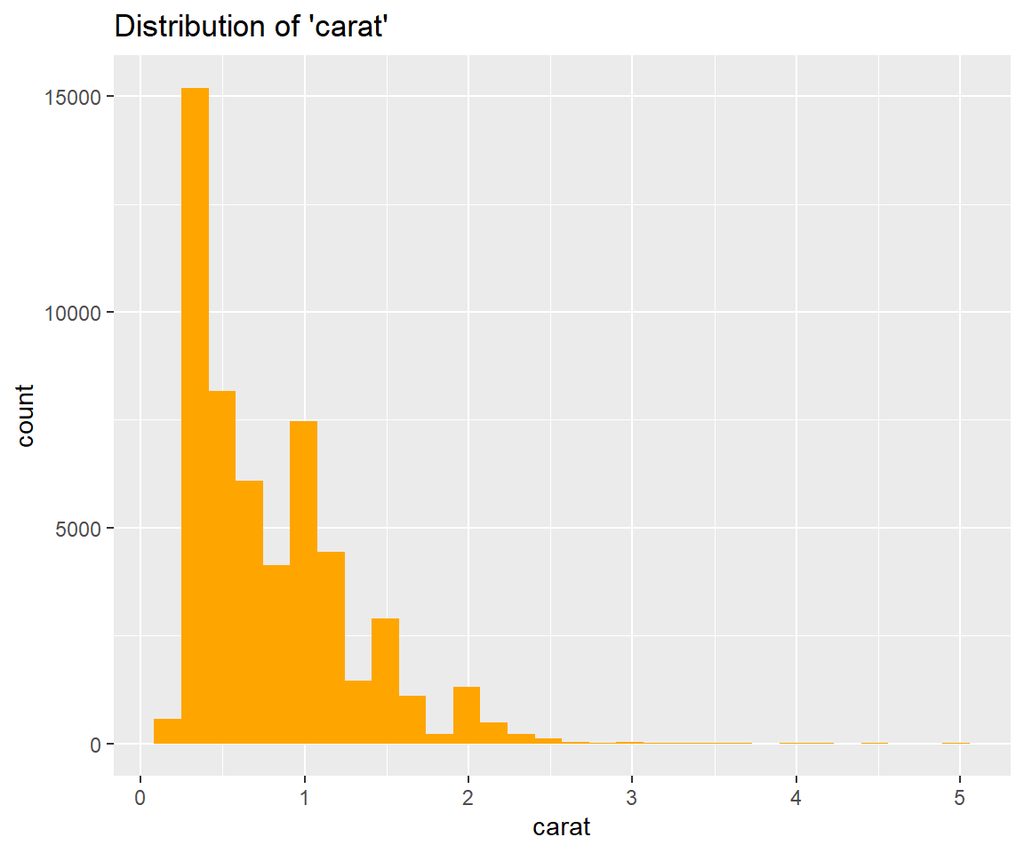

```r
ggplot(diamonds, aes(x = carat)) +
  geom_histogram(fill = "orange") +
  ggtitle("Distribution of 'carat'")
```

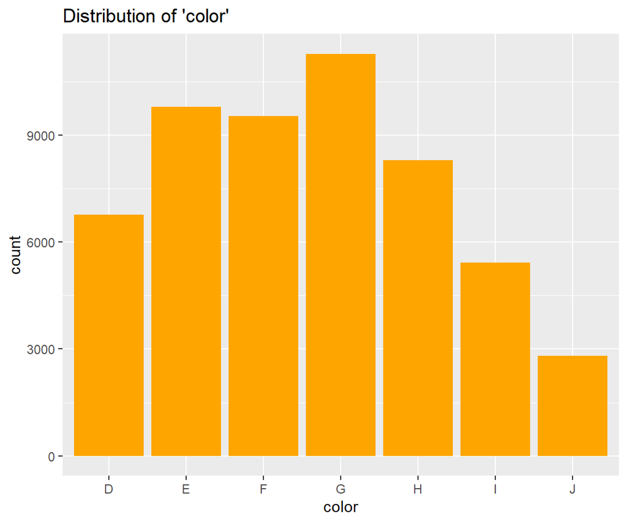

```r
ggplot(diamonds, aes(x = color)) +
  geom_bar(fill = "orange") +
  ggtitle("Distribution of 'color'")
```

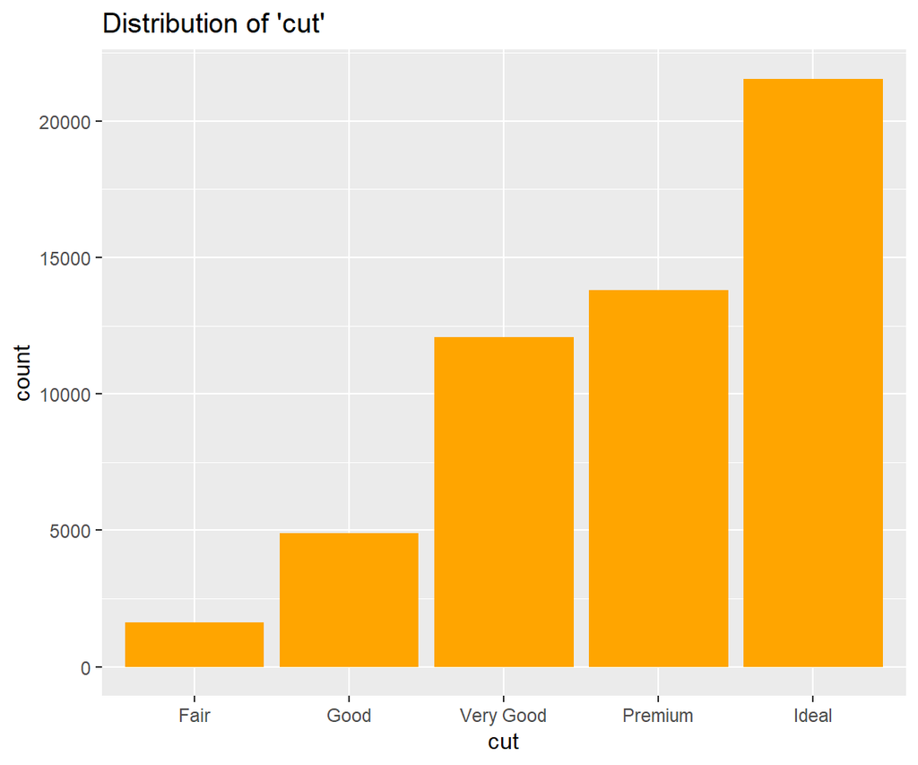

```r
ggplot(diamonds, aes(x = cut)) +
  geom_bar(fill = "orange") +
  ggtitle("Distribution of 'cut'")
```

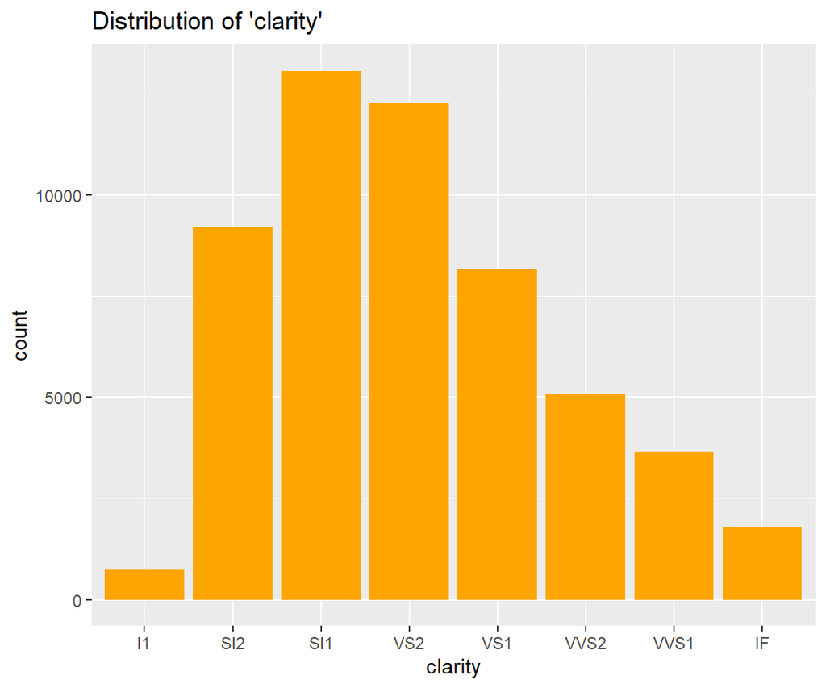

```r
ggplot(diamonds, aes(x = clarity)) +
  geom_bar(fill = "orange") +
  ggtitle("Distribution of 'clarity'")
```

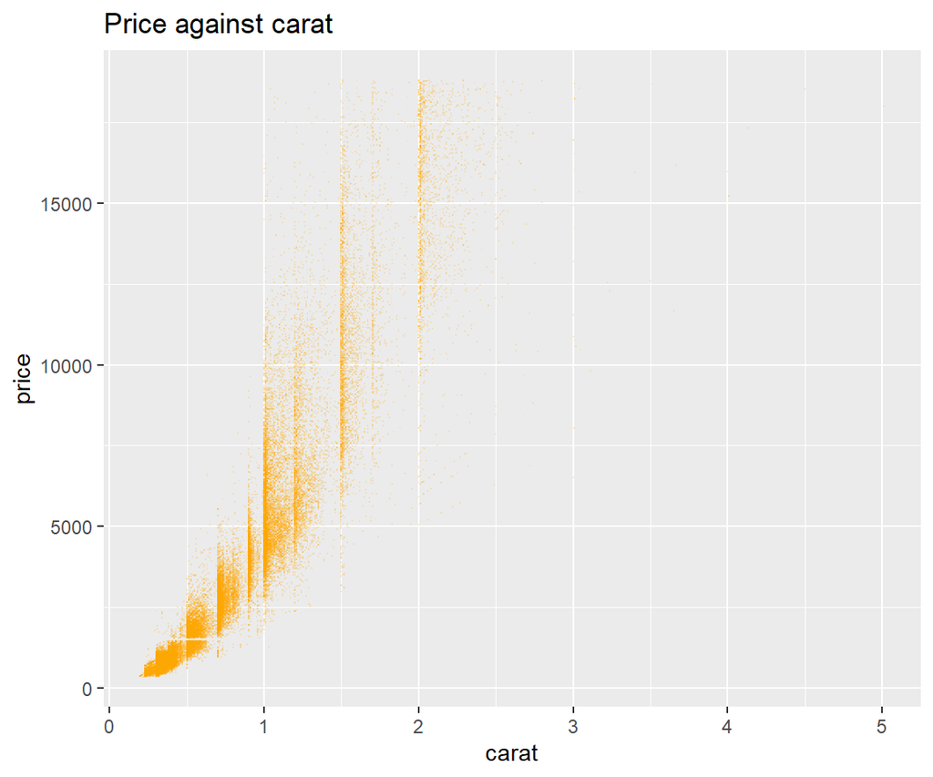

```r
# Selected bivariate descriptions
ggplot(diamonds, aes(y = price, x = carat)) +
  geom_point(alpha = 0.2, shape = ".", color = "orange") +
  ggtitle("Price against carat")
```

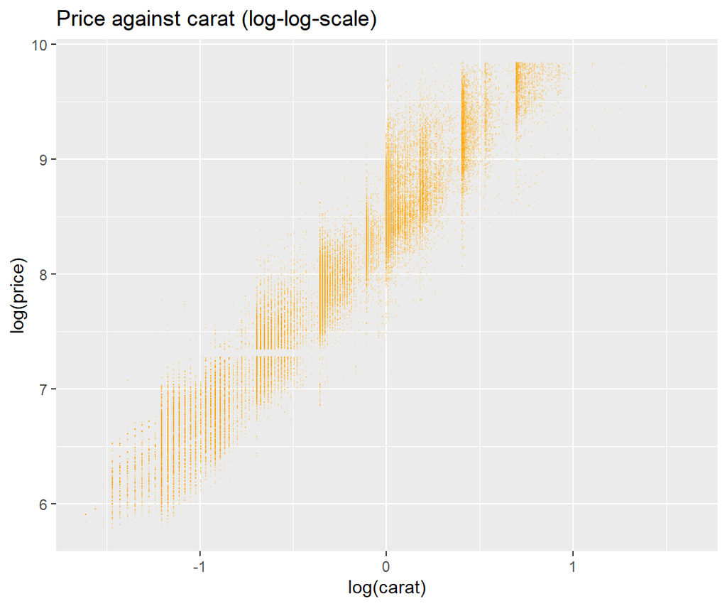

```r
ggplot(diamonds, aes(y = log(price), x = log(carat))) +
  geom_point(alpha = 0.2, shape = ".", color = "orange") +
  ggtitle("Price against carat (log-log-scale)")
```

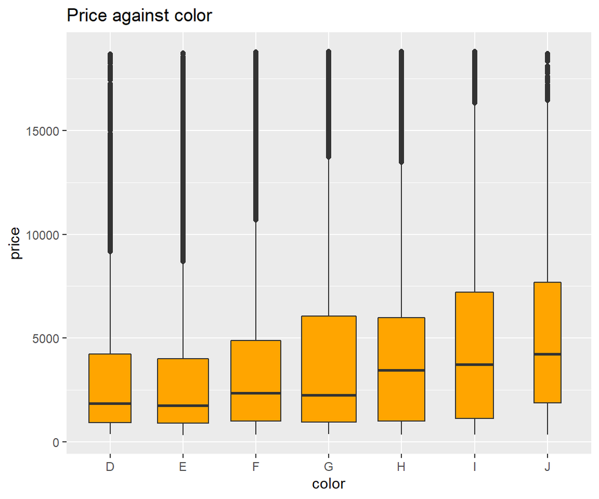

```r
ggplot(diamonds, aes(y = price, x = color)) +
  geom_boxplot(fill = "orange", varwidth = TRUE) +
  ggtitle("Price against color")
```

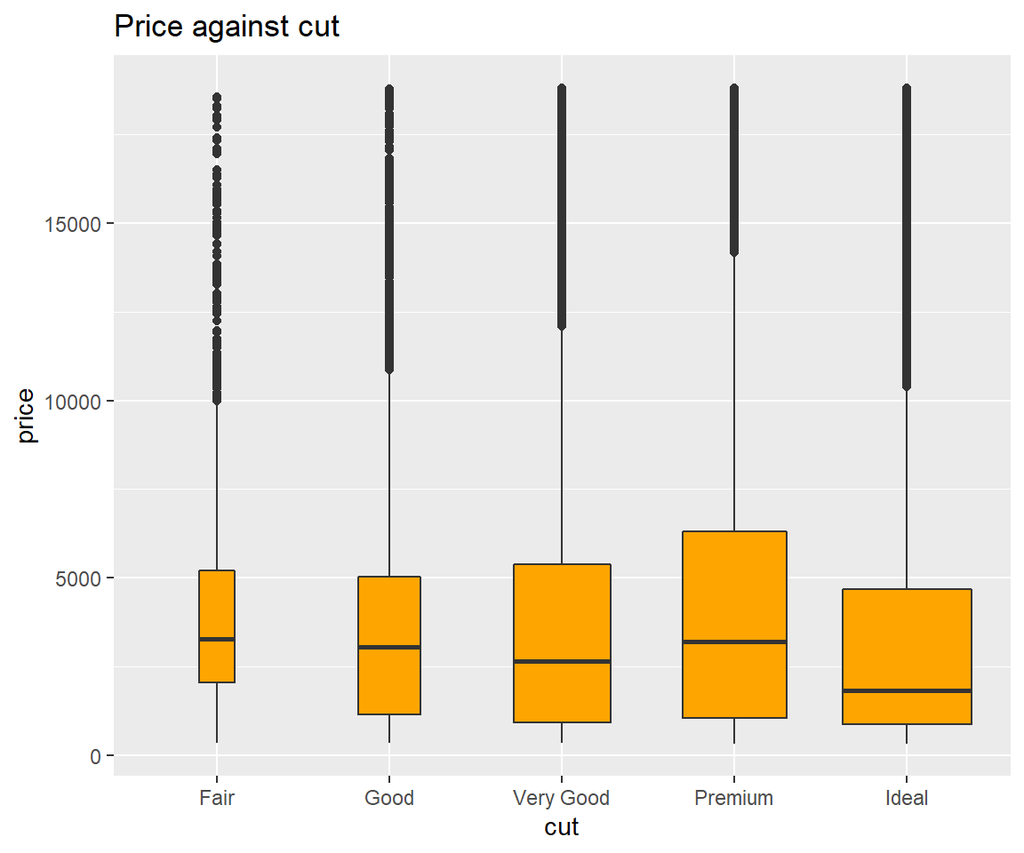

```r
ggplot(diamonds, aes(y = price, x = cut)) +
  geom_boxplot(fill = "orange", varwidth = TRUE) +
  ggtitle("Price against cut")
```

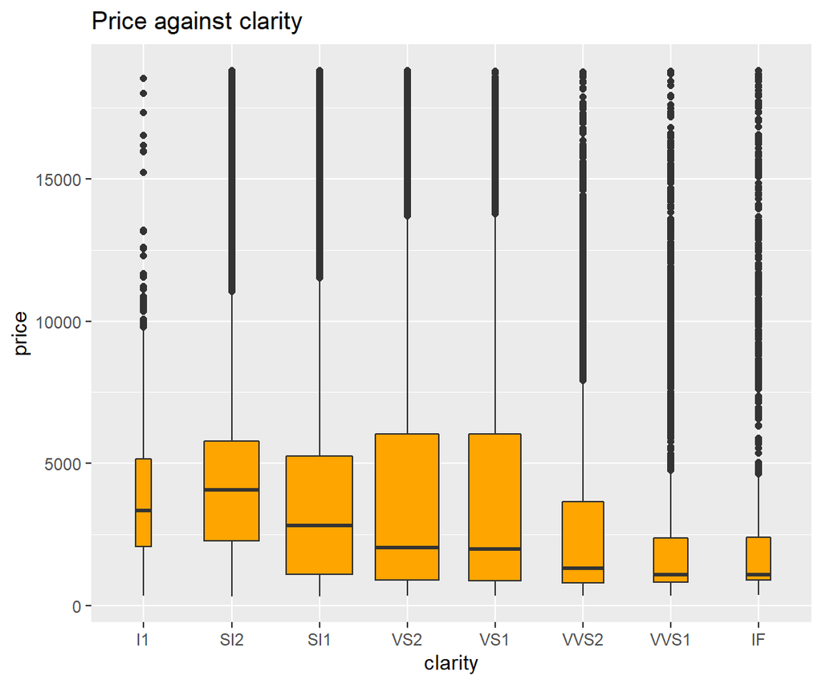

```r
ggplot(diamonds, aes(y = price, x = clarity)) +
  geom_boxplot(fill = "orange", varwidth = TRUE) +
  ggtitle("Price against clarity")
```

**Comments**

- There are 53’940 observations in the diamonds data set.
- The average or mean diamond price is 3933 USD. About half of the diamonds cost less/more than the median of 2401 USD and about half of them cost between 950 USD (first quartile) and 5324 USD (third quartile). The lowest price is 326 USD, the highest price is 18’823 USD.
- Prices and carats show a *right-skewed* distribution with a few very large values.
- The relationship between price and carat seems quite strong and positive, which makes sense. On log-log scale, it looks linear.
- The worst categories of `color`, `cut`, and `clarity` are rare.
- Prices tend to be lower for nice colors, nice cuts as well as for nice clarities. This unintuitive behaviour will be entangled later by our regression models.

## 1.4 Statistical models

The general modeling task is as follows: we want to approximate a *response variable* $Y$ by a function $f$ of $m$ *covariates* $X_1, \dots, X_m$, i.e.,
$$Y \approx f(X_1, \dots, X_m).$$
The function $f$ is unknown and we want to estimate it by $\hat f$ from observed data.

Note: Think of the response $Y$ and the covariates $X_1, \dots, X_m$ as columns in a data set.

Normally, we are interested in modeling a specific property of $Y$, usually its expectation $E(Y)$ (= theoretic mean). In that case, we can make above approximate relationship more explicit by writing down the *model equation*
$$E(Y) = f(X_1, \dots, X_m).$$

Once found, $\hat f$ serves as our prediction function that can be applied to fresh data. Furthermore, we can investigate the structure of $\hat f$ to gain insights about the relationship between response and covariates: what variables are especially important? how do they influence the response?

**Remark:** Other terms for “response variable” are “output”, “target” or “dependent variable”. Other terms for “covariate” are “input”, “feature”, “independent variable” or “predictor”.

# 2 Linear Regression

In order to get used to the terms mentioned above, we will look at the mother of all machine learning algorithms: (multiple) linear regression. It was first published by Adrien-Marie Legendre in 1805 [1] and is still very frequently used thanks to its simplicity, interpretability, and flexibility. It further serves as a simple benchmark for more complex algorithms and is the starting point for extensions like the generalized linear model.

## 2.1 Model equation

The model equation of the linear regression is as follows:
$$E(Y) = f(X_1, \dots, X_m) = \beta_0 + \beta_1 X_1 + \cdots + \beta_m
X_m.$$
It relates the covariates $X_1, \dots, X_m$ to the expected response $E(Y)$ by a *linear* formula in the parameters $\beta_0, \dots, \beta_m$. The additive constant $\beta_0$ is called the *intercept*. The parameter $\beta_j$ tells us by how much $Y$ is expected to change when $X_j$ is increased by 1, **keeping all other covariates fixed** (“Ceteris Paribus”). Indeed:
$$E(Y \mid X_j = x + 1) - E(Y \mid X_j = x) = \beta_j (x + 1) - \beta_j
x = \beta_j.$$
The parameter $\beta_j$ is called *effect* of $X_j$ on the expected response $E(Y)$.

A linear regression with just one covariate is called a *simple* linear regression with equation
$$E(Y) = \alpha + \beta X.$$

## 2.2 Least-squares

The optimal $\hat f$ to estimate $f$ is found by minimizing the sum of squared *prediction errors* (*residuals*)
$$\sum_{i=1}^n e_i^2 = \sum_{i=1}^n (y_i - \hat y_i)^2.$$
$y_i$ is the observed response of observation $i$ and $\hat y_i$ its prediction (or *fitted value*)
$$\hat y_i = \hat f(\text{Values of covariates of observation } i).$$

Once the model is fitted, we can use the coefficients $\hat\beta_0, \dots, \hat\beta_m$ to make predictions and to study empirical effects of the covariates on the expected response.

### 2.2.1 Example: simple linear regression

In order to discuss the typical output of a linear regression, we will now model diamond prices by their size. The model equation is
$$E(\text{price}) = \alpha + \beta \cdot \text{carat}.$$

```r
library(ggplot2)

fit <- lm(price ~ carat, data = diamonds)
summary(fit)
```

```
##
## Call:
## lm(formula = price ~ carat, data = diamonds)
##
## Residuals:
##      Min       1Q   Median       3Q      Max
## -18585.3   -804.8    -18.9    537.4  12731.7
##
## Coefficients:
##             Estimate Std. Error t value Pr(>|t|)
## (Intercept) -2256.36      13.06  -172.8   <2e-16 ***
## carat        7756.43      14.07   551.4   <2e-16 ***
## ---
## Signif. codes:  0 '***' 0.001 '**' 0.01 '*' 0.05 '.' 0.1 ' ' 1
##
## Residual standard error: 1549 on 53938 degrees of freedom
## Multiple R-squared:  0.8493, Adjusted R-squared:  0.8493
## F-statistic: 3.041e+05 on 1 and 53938 DF,  p-value: < 2.2e-16
```

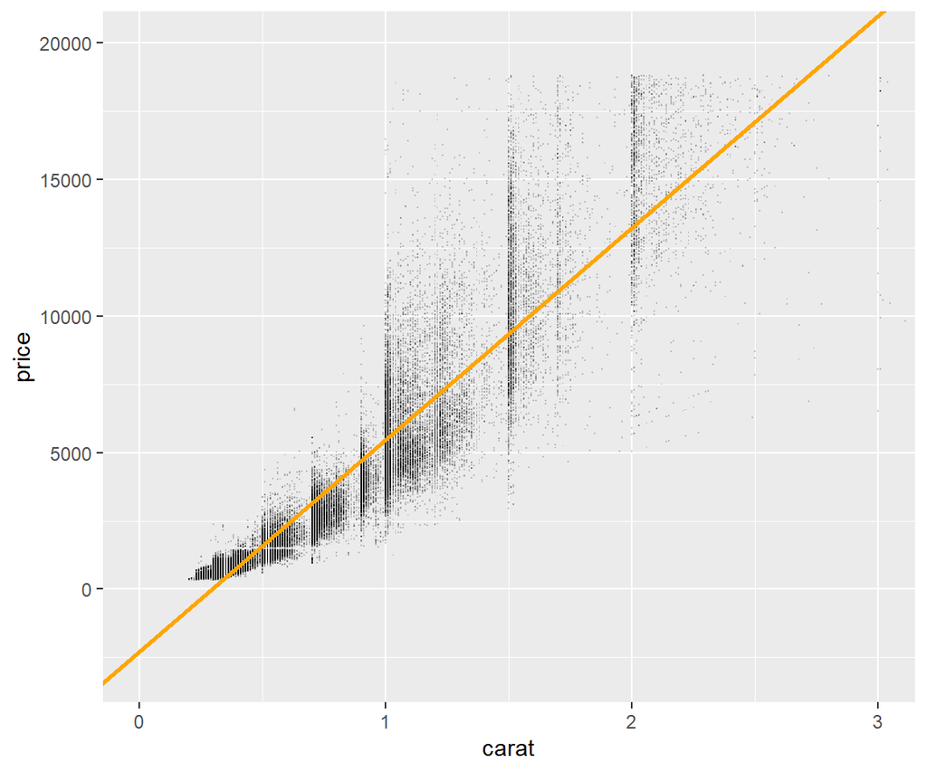

```r
intercept <- coef(fit)[[1]]
slope <- coef(fit)[[2]]

# Visualize the regression line
ggplot(diamonds, aes(x = carat, y = price)) +
  geom_point(alpha = 0.2, shape = ".") +
  coord_cartesian(xlim = c(0, 3), ylim = c(-3000, 20000)) +
  geom_abline(slope = slope, intercept = intercept, color = "orange", size = 1)
```

```r
# Predictions for diamonds with 1.3 carat?
predict(fit, data.frame(carat = 1.3))
```

```
##        1
## 7826.993
```

```r
# By hand
intercept + slope * 1.3
```

```
## [1] 7826.993
```

**Comments**

- **Regression coefficients:** The intercept $\alpha$ is estimated by $\hat \alpha = -2256$ and the effect of carat $\beta$ by $\hat \beta = 7756$ USD. This means that a 1 carat increase goes along with an average increase in price of 7756 USD. Similarly, we could say that a 0.1 increase in carat is associated with an increase in the price of 775.6 USD.
- **Regression line:** For a simple linear regression, the estimated regression coefficients $\hat \alpha$ and $\hat \beta$ can be visualized as a regression line. The latter represents the scatterplot as good as possible in the sense that the sum of squared vertical distances from the points to the line are minimal. The $y$-value at $x = 0$ equals $\hat \alpha = -2256$ and the slope of the line is $\hat \beta = 7756$.
- **Predictions:** Model predictions are made by using the fitted model equation $-2256 + 7756 \cdot \text{carat}$. For a diamond of size 1.3 carat, we get $-2256 + 1.3 \cdot 7756 \approx 7827$. These values correspond to the values on the regression line.

## 2.3 Quality of the model

How good is a specific linear regression model? We may consider two aspects, namely

- its predictive performance and
- how well its assumptions are valid.

### 2.3.1 Predictive performance

How precise are the model predictions? I.e., how well do predictions correspond with the observed response? In line with the least-squares approach, this is best quantified by the sum of squared prediction errors
$$\sum_{i = 1}^n (y_i - \hat y_i)^2$$
or, equivalently, by the *mean-squared-error*
$$\text{MSE} = \frac{1}{n}\sum_{i = 1}^n (y_i - \hat y_i)^2.$$
To quantify the size of the typical prediction error on the same scale as $Y$, we can take the square-root of the MSE and study the *root-mean-squared error* (RMSE). Minimizing MSE also minimizes RMSE.

Remark: The squared error, i.e., the function that quantifies the prediction error or *loss* of a single observation, is an example of a *loss function*. Later, we will meed other loss functions. Generally speaking, supervised ML algorithms try to minimize as objective function the total (or average) loss over the training sample, eventually adding a regularization penalty against overfitting. Overfitting is the tendency of the model to learn the training dataset by heart, i.e., it performs much better on the training data than on unseen data. The losses can be weighted in order to deal with case weights.

Besides an *absolute* performance measure like the RMSE, we gain additional insights by studying a relative performance measure like the **R-squared**. It measures the relative decrease in MSE compared to the MSE of the “empty” or “null” model consisting only of an intercept. Put differently, the R-squared measures the proportion of variability of $Y$ explained by the covariates.

#### 2.3.1.1 Example: simple linear regression (continued)

Let us calculate these performance measures for the simple linear regression above.

```r
mse <- function(y, pred) {
  mean((y - pred)^2)
}

(MSE <- mse(diamonds$price, predict(fit, diamonds)))
```

```
## [1] 2397955
```

```r
(RMSE <- sqrt(MSE))
```

```
## [1] 1548.533
```

```r
empty_model <- lm(price ~ 1, data = diamonds)  # predictions equal mean(diamonds$price)
MSE_empty <- mse(diamonds$price, predict(empty_model, diamonds))

# R-squared
(MSE_empty - MSE) / MSE_empty
```

```
## [1] 0.8493305
```

**Comments**

- **RMSE:** The RMSE is 1549 USD. This means that residuals (= prediction errors) are typically around 1549 USD.
- **R-squared:** The R-squared shows that about 85% of the price variability can be explained by variability in carat.

### 2.3.2 Model assumptions

The main assumption of linear regression is a **correctly specified model equation** in the sense that predictions are not systematically too high or too small for certain values of the covariates. In a simple regression setting, this means that the points in the scatterplot are located *around* the regression line for all covariate values. For a multiple linear regression, this translates to the empirical condition that residuals (differences between observed and fitted response) do not show bias if plotted against covariate values.

Additional assumptions like independence of rows, constant variance of the error term $\varepsilon$ in the equation
$$Y = f(X_1, \dots, X_m) + \varepsilon$$
and normal distribution of $\varepsilon$ guarantee optimality of the least-squares estimator $\hat \beta_0, \dots, \hat\beta_m$ and the correctness of inferential statistics (standard errors, p values, confidence intervals). In that case, we talk of the *normal linear model*. Its conditions are checked by studying *diagnostic plots*. We skip this part for brevity and since we are not digging into inferential statistics.

#### 2.3.2.1 Example: simple linear regression (continued)

When looking at the scatter plot enhanced with the regression line from above, we can spot systematically too low (even negative!) predictions for very small diamonds. This indicates a wrongly specified model. Later, we will see ways to fix this.

## 2.4 Typical problems

Here, we list some problems that frequently occurs with linear regression. We will only mention them without going into details.

### 2.4.1 Missing values

Like many other ML algorithms, linear regression cannot deal with missing values. Rows with missing response can be safely dropped, while missing values in covariates should usually be dealt with. The simplest (often too naive) approach is to fill missing values with a typical value such as the mean or the most frequent value.

### 2.4.2 Outliers

Gross outliers in covariates can distort the result of the linear regression. Do not delete them, but try to reduce their effect by taking logarithms or by using more robust regression techniques. Outliers in the response can be problematic as well, especially for inferential statistics.

### 2.4.3 Overfitting

If too many parameters are used in relation to the number of observations, the resulting model might look good but would not generalize well to new data. This is called overfitting. A small amount of overfitting is unproblematic. Do not fit a model with $m=100$ parameters on a data set with just $n=200$ rows. The resulting model would be garbage. A $n/m$ ratio of 50-100 is usually safe for stable estimation of parameters.

### 2.4.4 Collinearity

If the association between two or more covariates is strong, their coefficients are difficult to interpret because the Ceteris Paribus clause is usually unnatural in such situations. In a house price model, for instance, it is unnatural to study the effect of an additional room, keeping living area fixed. This is even more problematic for causally dependent covariates: imagine a model with $x$ and $x^2$ as covariates. It would certainly not make sense to study the effect of $x$ while keeping $x^2$ fixed.

Strong collinearity can be detected by looking at correlations across (numeric) covariates. It is mainly a problem when interpreting effects or for statistical inference of effects. Predictions or other “global” model characteristics like the R-squared are not affected.

Often, collinearity can be reduced by transforming the covariates in a way that makes the Ceteris Paribus clause natural. Instead of, e.g., using number of rooms and living area in a house price model, it might help to represent living area by the derived variable “living area per room”.

Note: Perfectly collinear covariates (for example $X$ and $2X$) cannot be used for algorithmic reasons.

## 2.5 Categorical covariates

Since algorithms usually only understand numbers, categorical variables have to be encoded by numbers. The standard approach is called **one-hot-encoding** (OHE) and works as follows: Each level $x_k$ of the categorical variable $X$ gets its own binary **dummy** variable $D_k = 1(X = x_k)$, indicating if $X$ has this particular value or not. In linear models, one of the dummy variables ($D_1$, say) needs to be dropped due to perfect collinearity (for each row, the sum of OHE variables is always 1). Its level is automatically being represented by the intercept. This variant of OHE is called **dummy coding**.

For our diamonds data set, OHE for the variable `color` looks as follows (the first column is the original categorical variable, the other columns are the dummy variables):

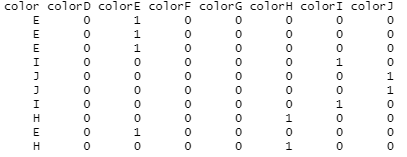

**Comments on categorical covariates**

- **Interpretation:** Interpreting the regression coefficient $\beta_k$ of the dummy variable $D_k$ is nothing special: It tells us how much $E(Y)$ changes when the dummy variable switches from 0 to 1. This amounts to switching from the reference category (the one without dummy) to category $k$.
- **Integer encoding:** Ordinal categorical covariates are sometimes integer encoded for simplicity, i.e., each category is represented by an integer number.
- **Small categories:** In order to reduce overfitting, small categories are sometimes combined to a level “Other” or are added to the largest category.

### 2.5.1 Example: dummy coding

Let us now extend the simple linear regression for diamond prices by adding dummy variables for the categorical covariate `color`.

```r
library(ggplot2)

fit <- lm(price ~ carat + factor(color, ordered = FALSE), data = diamonds)
summary(fit)
```

```
##
## Call:
## lm(formula = price ~ carat + factor(color, ordered = FALSE),
##     data = diamonds)
##
## Residuals:
##      Min       1Q   Median       3Q      Max
## -18345.1   -765.8    -72.8    558.5  12288.9
##
## Coefficients:
##                                 Estimate Std. Error  t value Pr(>|t|)
## (Intercept)                     -2136.23      20.12 -106.162  < 2e-16 ***
## carat                            8066.62      14.04  574.558  < 2e-16 ***
## factor(color, ordered = FALSE)E   -93.78      23.25   -4.033 5.51e-05 ***
## factor(color, ordered = FALSE)F   -80.26      23.40   -3.429 0.000605 ***
## factor(color, ordered = FALSE)G   -85.54      22.67   -3.773 0.000161 ***
## factor(color, ordered = FALSE)H  -732.24      24.35  -30.067  < 2e-16 ***
## factor(color, ordered = FALSE)I -1055.73      27.31  -38.657  < 2e-16 ***
## factor(color, ordered = FALSE)J -1914.47      33.78  -56.679  < 2e-16 ***
## ---
## Signif. codes:  0 '***' 0.001 '**' 0.01 '*' 0.05 '.' 0.1 ' ' 1
##
## Residual standard error: 1472 on 53932 degrees of freedom
## Multiple R-squared:  0.864,  Adjusted R-squared:  0.8639
## F-statistic: 4.893e+04 on 7 and 53932 DF,  p-value: < 2.2e-16
```

**Comments**

- **Slope:** Adding the covariate `color` has changed the slope of `carat` from 7756 in the simple linear regression to 8067. This is the effect of `carat` *adjusted* for `color`.
- **Effects:** Each dummy variable of `color` has received its own coefficient. Switching from the reference color “D” to “E” is associated with a price reduction of 94 USD. The effect of color “F” compared to color “D” is about -80 USD.
- **Confounding:** In contrast to the unintuitive descriptive result (worse colors tend to higher prices), worse colors are associated with lower prices now. Adjusting for carat has solved that mystery. It seems that the diamond size had *confounded* the association between color and price. A regression model accounts for such confounding effects.

## 2.6 Flexibility

Linear regression is flexible regarding *how* variables are represented in the linear equation. Possibilities include

- using non-linear terms,
- interactions, and
- transformations, notably logarithmic responses.

These elements are very important for making realistic models.

### 2.6.1 Non-linear terms

Important numeric covariates might be represented by more than just one parameter (= linear slope) to allow for more flexible and non-linear associations to the response. Adding a squared term, e.g., allows for curvature, adding enough multiple polynomial terms can approximate any smooth relationship.

For example, the model equation for a cubic regression is
$$E(Y) = \beta_0 + \beta_1 x + \beta_2 x^2 + \beta_3x^3.$$
An alternative to polynomial terms are regression *splines*, i.e., piecewise polynomials. Using non-linear terms makes interpretation of regression coefficients difficult. An option is to study predictions while sliding the covariate values over its range (systematic predictions).

#### 2.6.1.1 Example: cubic regression

How would a cubic regression approximate the relationship between diamond prices and carat?

The polynomial terms used for modeling look as follows:

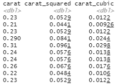

And here the model including systematic predictions.

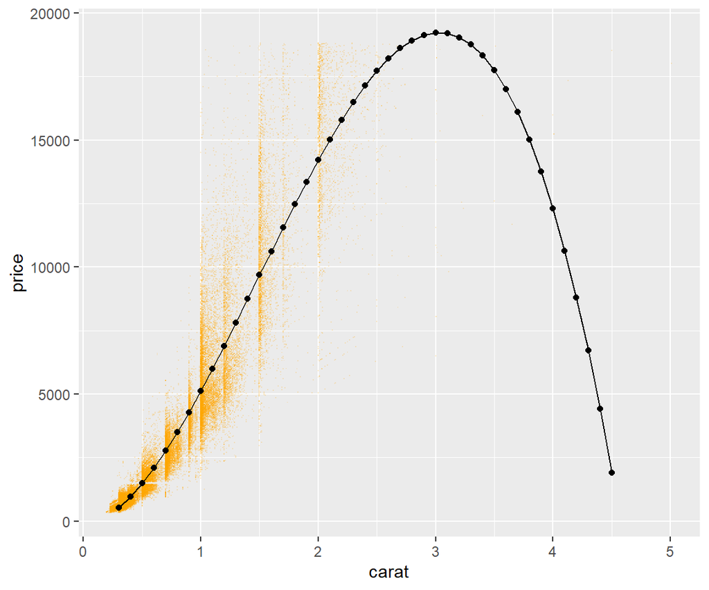

```r
library(tidyverse)

fit <- lm(price ~ poly(carat, 3), data = diamonds)

# Plot effect of carat on average price
data.frame(carat = seq(0.3, 4.5, by = 0.1)) %>%
  mutate(price = predict(fit, .)) %>%
ggplot(aes(x = carat, y = price)) +
  geom_point(data = diamonds, shape = ".", alpha = 0.2, color = "orange") +
  geom_line() +
  geom_point()
```

### 2.6.2 Interaction terms

Once fitted, the effect of a covariate does not depend on the values of the other covariates. This is a direct consequence of the additivity of the model equation. The additivity assumption is sometimes too strict. E.g., treatment effects might be larger for younger patients than for older. Or an extra 0.1 carat of diamond weight is worth more for a beautiful white diamond compared to an unspectacular yellow one. In such cases, adding *interaction terms* provides the necessary flexibility. Mathematically, an interaction term between covariates $X$ and $Z$ equals their product. Practically, it means that the effect $X$ depends on the value of $Z$.

**Comments**

- Adding interaction terms makes model interpretation difficult.
- Interaction terms mean more parameters, thus there is a danger of overfitting. Finding the right interaction terms without introducing overfitting is difficult or even impossible.
- Modern ML algorithms like neural networks and tree-based models automatically find interactions, even between more than two variables. This is one of their main strengths.

#### 2.6.2.1 Example: interactions

Let us now fit a linear regression for diamond prices with covariates `carat` and `color`, once without and once with interaction. We interpret the resulting models by looking at systematic predictions (sliding both carat and color over their range).

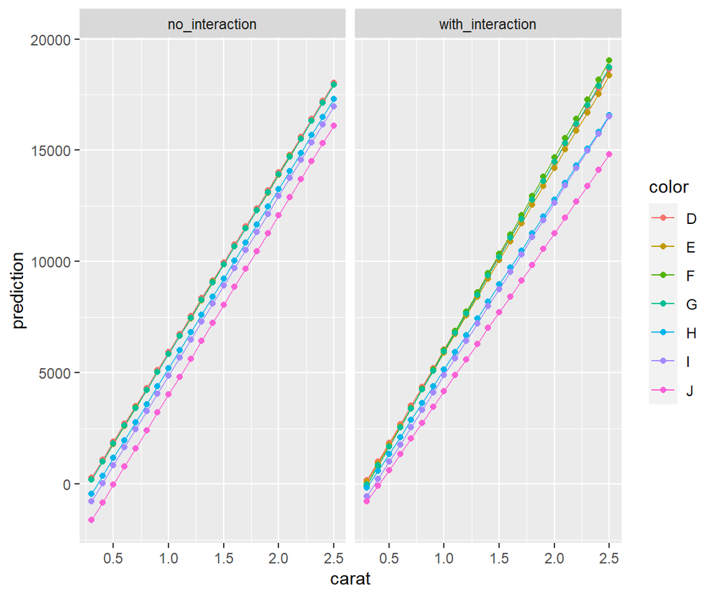

```r
library(tidyverse)

no_interaction <- lm(
  price ~ carat + factor(color, ordered = FALSE),
  data = diamonds
)
with_interaction <- lm(
  price ~ carat * factor(color, ordered = FALSE),
  data = diamonds
)

# Plot effect of carat grouped by color
to_plot <- expand.grid(
    carat = seq(0.3, 2.5, by = 0.1),
    color = levels(diamonds$color)
  ) %>%
  mutate(
    no_interaction = predict(no_interaction, .),
    with_interaction = predict(with_interaction, .)
  ) %>%
  pivot_longer(
    ends_with("interaction"),
    names_to = "model",
    values_to = "prediction"
  )

ggplot(to_plot, aes(x = carat, y = prediction, group = color, color = color)) +
  geom_line() +
  geom_point() +
  facet_wrap(~ model)
```

### 2.6.3 Transformations of covariates

Covariates are often transformed before entering the model:

- Categorical covariates are dummy coded.
- Strongly correlated covariates might be decorrelated by forming ratios.
- Logarithms neutralize gross outliers.

Not surprisingly, coefficients explain how the *transformed* variables acts on the expected response. For a log-transformed covariate $X$, we can even interpret the coefficient regarding the **untransformed** $X$. In the model equation
$$E(Y\mid X = x) = \alpha + \beta \log(x),$$
we can say: A 1% increase in $X$ leads to an increase in $E(Y)$ of about $\beta/100$. Indeed, we have
$$E(Y\mid X = 101\% \cdot x) - E(Y\mid X = x) = \alpha + \beta \log
(1.01 \cdot x) - \alpha - \beta \log(x) \\
= \beta \log\left(\frac{1.01 \cdot x}{x}\right)= \beta \log(1.01)
\approx \beta/100.$$
Thus, taking logarithms of covariates not only deals with outliers, it also offers us the possibility to talk about percentages.

#### 2.6.3.1 Example: log(carat)

What would our simple linear regression provide with logarithmic carat as single covariate?

```r
library(tidyverse)

fit <- lm(price ~ log(carat), data = diamonds)
fit
```

```
##
## Call:
## lm(formula = price ~ log(carat), data = diamonds)
##
## Coefficients:
## (Intercept)   log(carat)
##        6238         5836
```

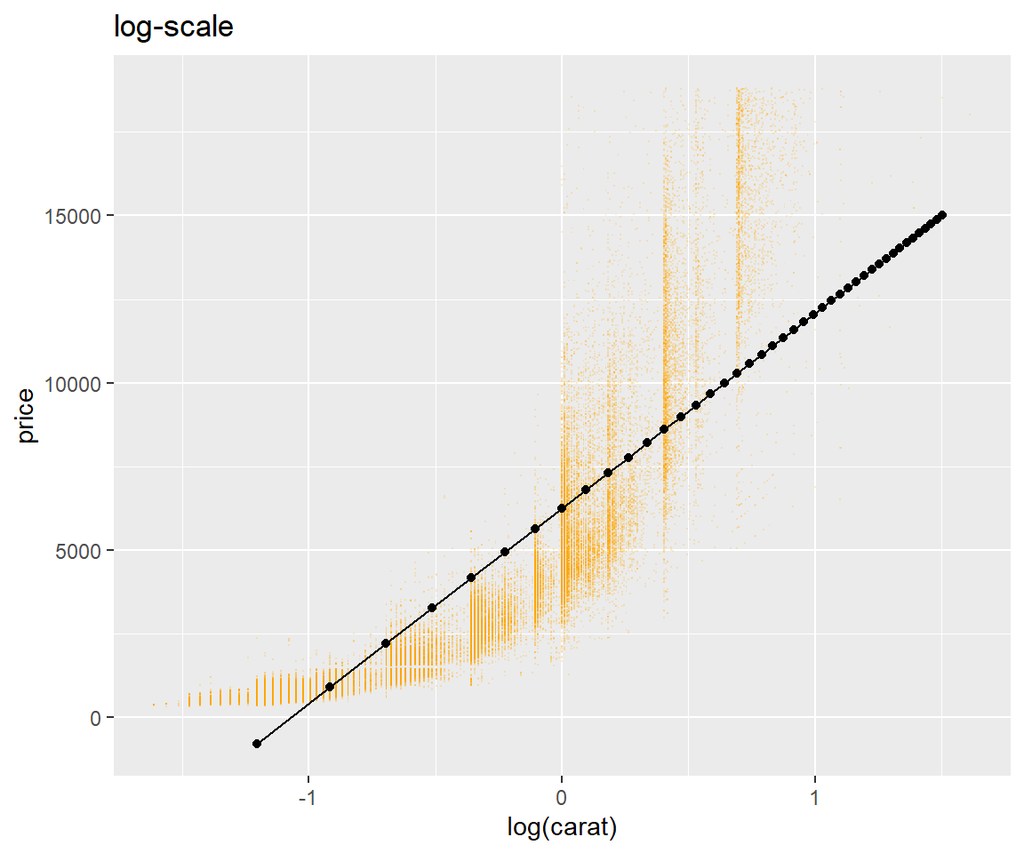

```r
to_plot <- data.frame(carat = seq(0.3, 4.5, by = 0.1)) %>%
  mutate(price = predict(fit, .))

# log-scale
ggplot(to_plot, aes(x = log(carat), y = price)) +
  geom_point(data = diamonds, shape = ".", alpha = 0.2, color = "orange") +
  geom_line() +
  geom_point() +
  ggtitle("log-scale")
```

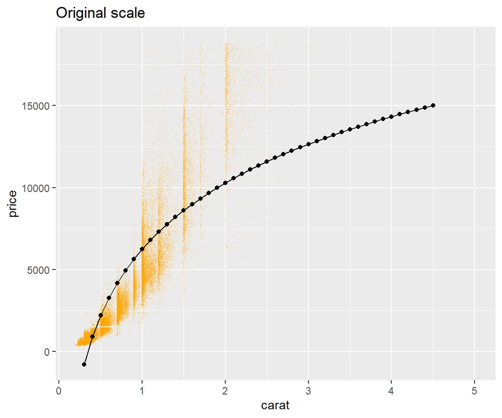

```r
# original scale
ggplot(to_plot, aes(x = carat, y = price)) +
  geom_point(data = diamonds, shape = ".", alpha = 0.2, color = "orange") +
  geom_line() +
  geom_point() +
  ggtitle("Original scale")
```

### 2.6.4 Logarithmic response

We have seen that taking logarithms not only reduces outlier effects in covariates but they also allow to think in percentages. What happens if we log-transform the response variable? The model of a simple linear regression would be
$$E(\log(Y) \mid X = x) = \alpha + \beta x.$$
**Claim:** The effect $\beta$ tells us by how much *percentage* we can expect $Y$ to change when increasing $X$ by 1. Thus, a logarithmic response leads to a *multiplicative* instead of an *additive* model.

**Proof**

Assume for a moment that we can swap taking expectations and logarithms (disclaimer: we cannot). In that case, the model would be

$$\log(E(Y\mid X = x)) = \alpha + \beta x$$
or, after exponentiation,
$$E(Y\mid X = x) =e^{\alpha + \beta x}.$$
The additive effect of increasing $X$ by 1 would be
$$E(Y\mid X = x+1) - E(Y\mid X = x) = e^{\alpha + \beta (x+1)} -
e^{\alpha + \beta x} \\
= e^{\alpha + \beta x}e^\beta - e^{\alpha + \beta x} = e^{\alpha +
\beta x}(e^\beta - 1) = E(Y\mid X = x)(e^\beta - 1).$$
Dividing both sides by $E(Y\mid X = x)$ gives
$$\underbrace{\frac{E(Y\mid X = x+1) - E(Y\mid X = x)}{E(Y\mid X =
x)}}_{\text{Relative change in } E(Y)} = e^\beta-1 \approx \beta = \beta
\cdot 100\%.$$
Indeed: A one point increase in $X$ is associated with a relative increase in $E(Y)$ of about $\beta \cdot 100\%$.

Since expectations and logarithms cannot be swapped, the calculation is not 100% correct. One consequence of this imperfection is that predictions backtransformed to the scale of $Y$ are biased. One of the motivations of the generalized linear models GLM (see next section) will be to mend this problem in an elegant way.

#### 2.6.4.1 Example: log(price)

How would our simple linear regression look like with `log(price)` as response?

```r
library(tidyverse)

fit <- lm(log(price) ~ carat, data = diamonds)
summary(fit)
```

```
##
## Call:
## lm(formula = log(price) ~ carat, data = diamonds)
##
## Residuals:
##     Min      1Q  Median      3Q     Max
## -6.2844 -0.2449  0.0335  0.2578  1.5642
##
## Coefficients:
##             Estimate Std. Error t value Pr(>|t|)
## (Intercept) 6.215021   0.003348    1856   <2e-16 ***
## carat       1.969757   0.003608     546   <2e-16 ***
## ---
## Signif. codes:  0 '***' 0.001 '**' 0.01 '*' 0.05 '.' 0.1 ' ' 1
##
## Residual standard error: 0.3972 on 53938 degrees of freedom
## Multiple R-squared:  0.8468, Adjusted R-squared:  0.8468
## F-statistic: 2.981e+05 on 1 and 53938 DF,  p-value: < 2.2e-16
```

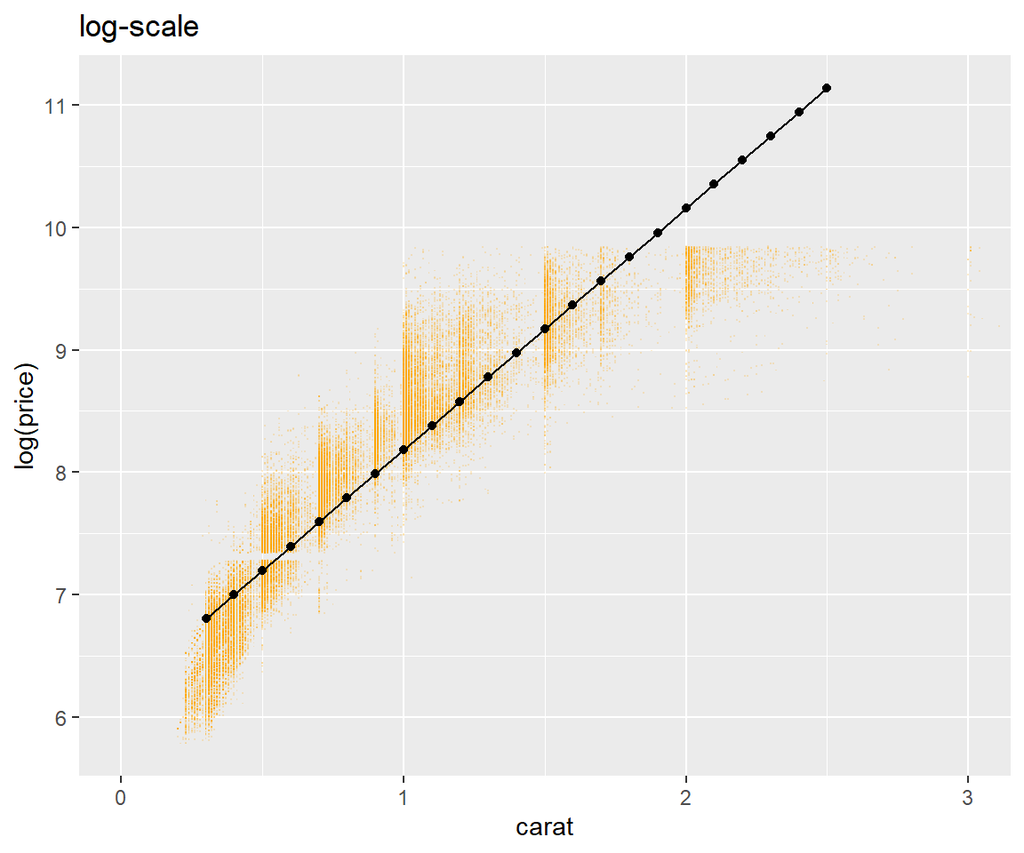

```r
to_plot <- data.frame(carat = seq(0.3, 2.5, by = 0.1)) %>%
  mutate(price = exp(predict(fit, .)))

# log-scale
ggplot(to_plot, aes(x = carat, y = log(price))) +
  geom_point(data = diamonds, shape = ".", alpha = 0.2, color = "orange") +
  geom_line() +
  geom_point() +
  coord_cartesian(x = c(0, 3)) +
  ggtitle("log-scale")
```

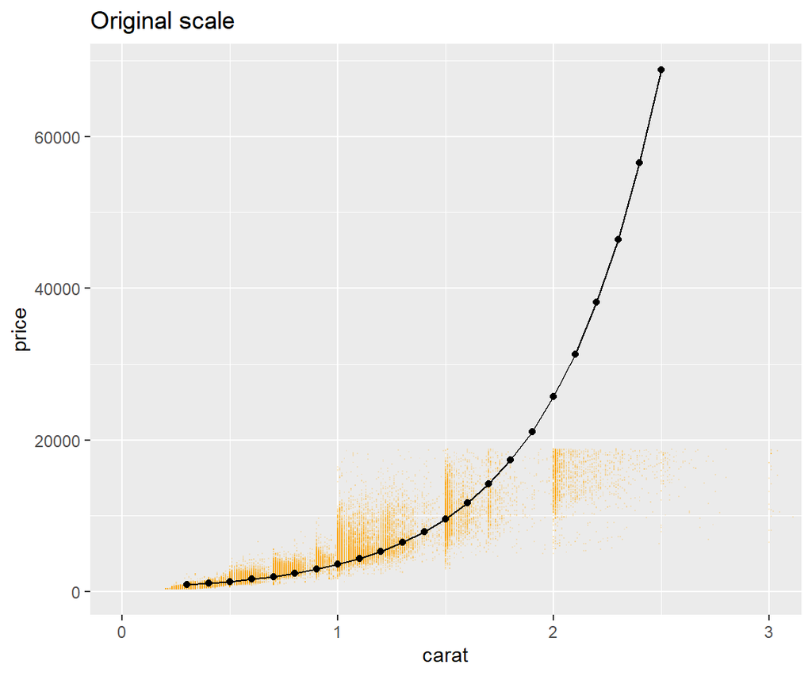

```r
# original scale
ggplot(to_plot, aes(x = carat, y = price)) +
  geom_point(data = diamonds, shape = ".", alpha = 0.2, color = "orange") +
  geom_line() +
  geom_point() +
  coord_cartesian(x = c(0, 3)) +
  ggtitle("Original scale")
```

**Comments**

- **General impression:** The model looks fine until 1.8 carat (both on log-scale and original scale). For larger diamonds, the model is heavily biased.
- **Interpretation on log-scale:** An increase in carat of 0.1 is associated with a log(price) increase of 0.197.
- **Interpretation on original scale:** An increase in carat of 0.1 is associated with a price increase of about 20%.
- **Predictions:** Predictions are obtained by exponentiating the result of the linear formula.
- **R-squared:** About 85% of the variability in log(price) can be explained by carat.
- **RMSE:** Typical prediction errors are in the range of 40%.

#### 2.6.4.2 Example: log(carat) and log(price)

Using logarithms for either price or carat did not provide a satisfactory model yet. What about applying logarithms to both response and covariate at the same time?

```r
library(tidyverse)

fit <- lm(log(price) ~ log(carat), data = diamonds)
summary(fit)
```

```
##
## Call:
## lm(formula = log(price) ~ log(carat), data = diamonds)
##
## Residuals:
##      Min       1Q   Median       3Q      Max
## -1.50833 -0.16951 -0.00591  0.16637  1.33793
##
## Coefficients:
##             Estimate Std. Error t value Pr(>|t|)
## (Intercept) 8.448661   0.001365  6190.9   <2e-16 ***
## log(carat)  1.675817   0.001934   866.6   <2e-16 ***
## ---
## Signif. codes:  0 '***' 0.001 '**' 0.01 '*' 0.05 '.' 0.1 ' ' 1
##
## Residual standard error: 0.2627 on 53938 degrees of freedom
## Multiple R-squared:  0.933,  Adjusted R-squared:  0.933
## F-statistic: 7.51e+05 on 1 and 53938 DF,  p-value: < 2.2e-16
```

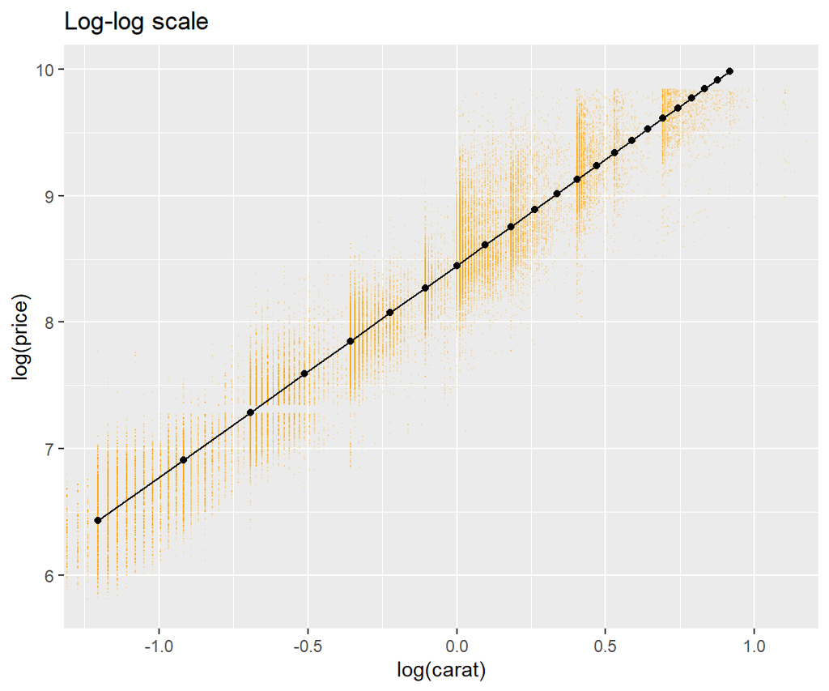

```r
to_plot <- data.frame(carat = seq(0.3, 2.5, by = 0.1)) %>%
  mutate(price = exp(predict(fit, .)))

# log-log-scale
ggplot(to_plot, aes(x = log(carat), y = log(price))) +
  geom_point(data = diamonds, shape = ".", alpha = 0.2, color = "orange") +
  geom_line() +
  geom_point() +
  coord_cartesian(x = log(c(0.3, 3))) +
  ggtitle("Log-log scale")
```

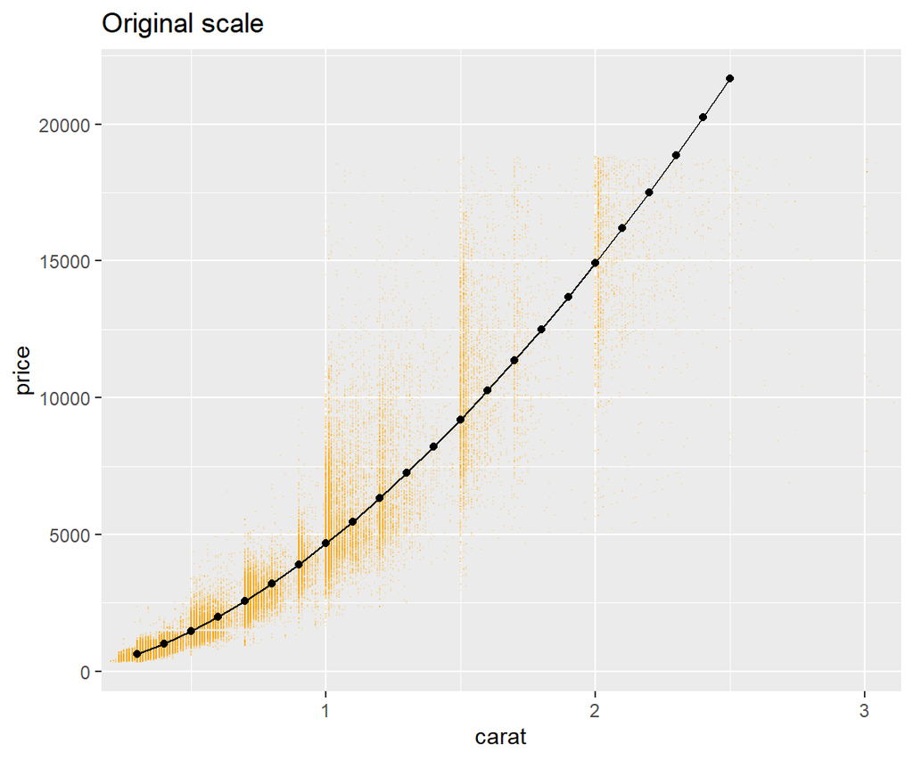

```r
# Back-transformed
ggplot(to_plot, aes(x = carat, y = price)) +
  geom_point(data = diamonds, shape = ".", alpha = 0.2, color = "orange") +
  geom_line() +
  geom_point() +
  coord_cartesian(x = c(0.3, 3)) +
  ggtitle("Original scale")
```

```r
# Relative bias on original scale
mean(diamonds$price) / mean(exp(fitted(fit))) - 1
```

```
## [1] 0.0313502
```

**Comments**

- **General impression:** The model looks quite realistic, both on log-log and back-transformed scale. There are no obvious model biases visible.
- **Effect on log-scales**: An increase in log(carat) of 1 is associated with a log(price) increase of 1.67.
- **Effect on original scales**: An increase in carat of 1% is associated with a price increase of about 1.67%.
- **R-squared:** About 93% of the variability in log(price) can be explained by log(carat). The model performs much better than the ones in the previous examples.
- **RMSE:** Typical prediction errors are in the range of 26%.
- **Bias:** While unbiased on the log scale, the predictions of this model are about 3% too small after exponentiation. This can be fixed by applying a corresponding bias correction factor.

## 2.7 Example: diamonds improved

To end the section on linear regression, we extend the log-log-example above by adding `color`, `cut` and `clarity` as categorical covariates.

```r
library(tidyverse)

dia <- diamonds %>%
  mutate_at(
    c("color", "cut", "clarity"),
    function(z) factor(z, ordered = FALSE)
  )

fit <- lm(log(price) ~ log(carat) + color + cut + clarity, data = dia)
summary(fit)
```

```
##
## Call:
## lm(formula = log(price) ~ log(carat) + color + cut + clarity,
##     data = dia)
##
## Residuals:
##      Min       1Q   Median       3Q      Max
## -1.01107 -0.08636 -0.00023  0.08341  1.94778
##
## Coefficients:
##               Estimate Std. Error t value Pr(>|t|)
## (Intercept)   7.856856   0.005758 1364.43   <2e-16 ***
## log(carat)    1.883718   0.001129 1668.75   <2e-16 ***
## colorE       -0.054277   0.002118  -25.62   <2e-16 ***
## colorF       -0.094596   0.002142  -44.16   <2e-16 ***
## colorG       -0.160378   0.002097  -76.49   <2e-16 ***
## colorH       -0.251071   0.002225 -112.85   <2e-16 ***
## colorI       -0.372574   0.002492 -149.50   <2e-16 ***
## colorJ       -0.510983   0.003074 -166.24   <2e-16 ***
## cutGood       0.080048   0.003890   20.57   <2e-16 ***
## cutVery Good  0.117215   0.003619   32.39   <2e-16 ***
## cutPremium    0.139345   0.003579   38.94   <2e-16 ***
## cutIdeal      0.161218   0.003548   45.44   <2e-16 ***
## claritySI2    0.427879   0.005178   82.64   <2e-16 ***
## claritySI1    0.592954   0.005149  115.17   <2e-16 ***
## clarityVS2    0.742164   0.005178  143.34   <2e-16 ***
## clarityVS1    0.812277   0.005257  154.52   <2e-16 ***
## clarityVVS2   0.947271   0.005418  174.83   <2e-16 ***
## clarityVVS1   1.018743   0.005575  182.73   <2e-16 ***
## clarityIF     1.113732   0.006030  184.69   <2e-16 ***
## ---
## Signif. codes:  0 '***' 0.001 '**' 0.01 '*' 0.05 '.' 0.1 ' ' 1
##
## Residual standard error: 0.1338 on 53921 degrees of freedom
## Multiple R-squared:  0.9826, Adjusted R-squared:  0.9826
## F-statistic: 1.693e+05 on 18 and 53921 DF,  p-value: < 2.2e-16
```

**Comments**

- **Effects:** All effects of the multiple linear regression look plausible.
- **Interpretation:** For every % more carat, we can expect an increase in price of about 1.9% (keeping everything else fixed). After all, a big diamond is worth more than its two halves. Diamonds with the second best color “E” are about 5% cheaper than those with the best color (keeping everything else fixed). The multiplicative effects of categorical covariates clearly make more sense here than the additive effects without logarithmic response.
- **R-squared:** About 98% of the variability in log-prices can be explained by our four covariates. Adding the three categorical covariates has considerably improved the precision of the model.
- **RMSE:** The typical prediction error is about 13%.

## 2.8 Exercises

As alternative to the multiple linear regression on diamond prices with logarithmic price and logarithmic carat, consider the same model without logarithms. Interpret the output of the model. Does it make sense from a practical perspective?

```r
library(tidyverse)

# Turn ordered factors into unordered ones
dia <- diamonds %>%
  mutate_at(
    c("color", "cut", "clarity"),
    function(z) factor(z, ordered = FALSE)
  )
```

# 3 Generalized Linear Model

The linear regression model has many extensions:

- quantile regression to model quantiles of the response instead of its expectation,
- mixed-models to capture grouped data structures,
- generalized least-squares to model time series data,
- penalized regression, an extension to fight overfitting (LASSO, Ridge-Regression, Elastic-Net),
- neural networks that automatically learn interactions and non-linearities (see later),
- **the generalized linear model** that e.g. allows to model binary response variables in a natural way,
- …

This section covers the generalized linear model (GLM). It was introduced in 1972 by Nelder & Wedderburn [2].

## 3.1 Definition

The model equation of the GLM is
$$g(E(Y)) = \beta_0 + \beta_1 X_1 + \dots + \beta_m X_m,$$
or similarly
$$E(Y) = g^{-1}(\beta_0 + \beta_1 X_1 + \dots + \beta_m X_m),$$
where $Y$ conditional on the covariates belongs to the so-called exponential dispersion family and $g$ is a transformation.

Thus, a GLM has three components:

1. A linear function of the covariates, exactly as in linear regression.
2. The link function $g$. Its purpose is to map $E(Y)$ to the scale of the linear function. Or the other way round: The inverse link $g^{-1}$ maps the linear part to the scale of the response.
3. A distribution of $Y$ conditional on the covariates. It implies the loss function to be minimized over the training sample.

The following table lists some of the most used GLMs.

| Regression | Distribution | Range of $Y$ | Natural link | Typical link | Loss function |
| --- | --- | --- | --- | --- | --- |
| Linear | Normal | $(-\infty, \infty)$ | Identity | Identity | Squared error: $(y - \hat y)^2$ |
| Logistic | Binary | $\{0, 1\}$ | logit | logit | Binary cross-entropy: $-(y\log(\hat y) + (1-y) \log(1-\hat y))$ |
| Poisson | Poisson | $[0, \infty)$ | log | log | Unit Poisson deviance: $2(y \log(y / \hat y) - (y - \hat y))$ |
| Gamma | Gamma | $(0, \infty)$ | 1/x | log | Unit Gamma deviance: $2 ((y - \hat y) / \hat y - \log(y / \hat y))$ |
| Multinomial | Multinomial | $\{C_1, \dots, C_m\}$ | mlogit | mlogit | Categorical cross-entropy: $-\sum_{j = 1}^m 1(y = C_j)\log(\hat y_j)$ |

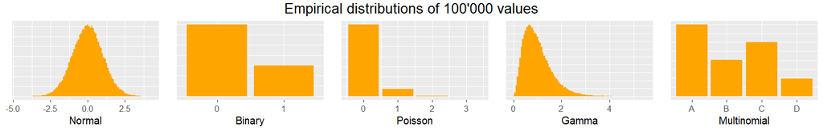

**Some remarks**

- To find predictions $\hat y$ on the scale of $Y$, one evaluates the linear function (called “linear predictor”) and then applies the inverse link $g^{-1}$.
- Any transformation can be used as link $g$. However, only the *natural/canonical* link has the relevant property of providing unbiased predictions on the scale of $Y$ in the sense $E(\hat y) = E(Y)$. Thus, one usually works with the natural link. Notable exception is the Gamma GLM, which is mostly applied with the log link because of the next property.
- **Using a log link produces a multiplicative model for $E(Y)$.**
- The binary case makes use of the relation $E(Y) = \text{Prob(Y = 1)} = p$, i.e., modeling the expected response is the same as modeling the probability $p$ of having a 1.
- The multinomial regression generalizes the binary case to more than two categories. While binary logistic regression predicts one single probability $\text{Prob}(Y=1)$, the multinomial model predicts a probability $\hat y_j$ for each of the m categories.
- The normal, Poisson and Gamma GLMs are special cases of the *Tweedie GLM*.

## 3.2 Why do we need GLMs?

The normal linear model allows us to model $E(Y)$ by an additive linear function. In principle, this would also work for

- binary responses (insurance claim yes/no, success yes/no, fraud yes/no, …),
- count responses (number of insurance claims, number of adverse events, …),
- right-skewed responses (time durations, claim heights, prices, …).

However, in such cases, an additive linear model equation is usually not very realistic. As such, the main assumption of the linear regression model is violated:

- Binary: A jump from 0.5 to 0.6 success probability seems less impressive than from 0.89 to 0.99.
- Count: A jump from an expected count of 2 to 3 seems less impressive than a jump from an expected count of 0.1 to 1.1.
- Right-skewed: A price jump from 1 Mio to 1.1 Mio is conceived as larger than a jump from 2 Mio to 2.1 Mio.

GLMs deal with such problems by using a suitable link function like the logarithm. At least for the first two examples, this could not be achieved by a linear regression with log response because log(0) is not defined.

Further advantages of the GLM over the linear regression are:

- Predictions are on the right scale: For instance, probabilities of a binary response are between 0 and 1 when using the logit link. With linear regression, they could be outside [0, 1]. Similarly, predictions of a Poisson or Gamma regression with log link are strictly positive, while they could be even negative with linear regression.
- Inferential statistics are less inaccurate. For the linear regression, they depend on the equal variance assumption which is violated for distributions like Poisson or Gamma.

## 3.3 Interpretation of effects

The interpretation of model coefficients in GLMs is guided by the link function.

- **Identity link:** As with linear regression: “A one-point increase in $X$ is associated with a $\beta$ increase in $E(Y)$, keeping everything else fixed”.
- **Log link:** As with linear regression with log response: “A one-point increase in $X$ is associated with a relative increase in $E(Y)$ of $e^{\beta}-1 \approx \beta \cdot 100\%$. The derivation is exactly as we have seen for linear regression, except that we now start with $\log(E(Y))$ instead of $E(\log(Y))$, making the former calculations mathematically sound. Using a GLM with log link is thus the cleaner way to produce a multiplicative model for $E(Y)$ than to log transform the response in a linear regression.
- **Logit link:** Logistic regression uses the logit link
  $$\text{logit}(p) = \log (\text{odds}(p)) =
  \log\left(\frac{p}{1-p}\right).$$
  It maps probabilities to the real line. The inverse logit (“sigmoidal transformation” or “logistic function”) reverts this: It maps real values to the range from 0 to 1. Odds, i.e., the ratio of $p$ to $1-p$, is a concept borrowed from gambling: The *probability* to get a “6” is 1/6 whereas the *odds* to get a “6” is 1:5 = 0.2. By definition, logistic regression is an additive model for the log-odds, thus a multiplicative model for the odds of getting a 1. Correspondingly, the coefficients $e^\beta - 1 \approx \beta$ are called *odds ratios*. There is no easy way to interpret the coefficients on the original probability scale.

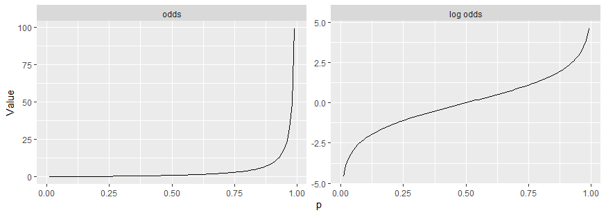

## 3.4 Parameter estimation and deviance

Parameters of a GLM are estimated by Maximum-Likelihood. This amounts to minimizing a distribution specific objective criterion called (total) *deviance*, which is proportional to the sum of the losses (see table above) of all rows, eventually weighted by case weights. For the normal linear model, deviance (divided by n) is equivalent to MSE. In fact, deviance plays the same role for GLMs as the MSE for linear regression. It sometimes makes sense to consider as a relative performance measure the relative deviance improvement compared to an empty model. For the normal linear regression model, this equals the usual R-squared.

Remark: The unit deviance of the logistic regression equals twice the binary *cross-entropy* (= “log loss”).

**Outlook:** The loss functions used in the context of GLMs are used one-to-one as loss functions for other ML methods like gradient boosting or neural networks. There, the “appropriate” loss function is chosen from the context. E.g., if the response is binary, one typically selects binary cross-entropy as the optimization criterion.

## 3.5 Example: Poisson count regression

We now model claim counts for the `insuranceData` by a Poisson GLM with its natural link function, the log. It makes sure that we can interpret covariate effects on a relative scale and that predictions are positive.

```r
library(ggplot2)
library(insuranceData)

data(dataCar)

summary(dataCar)
```

```
##    veh_value         exposure             clm            numclaims
##  Min.   : 0.000   Min.   :0.002738   Min.   :0.00000   Min.   :0.00000
##  1st Qu.: 1.010   1st Qu.:0.219028   1st Qu.:0.00000   1st Qu.:0.00000
##  Median : 1.500   Median :0.446270   Median :0.00000   Median :0.00000
##  Mean   : 1.777   Mean   :0.468651   Mean   :0.06814   Mean   :0.07276
##  3rd Qu.: 2.150   3rd Qu.:0.709103   3rd Qu.:0.00000   3rd Qu.:0.00000
##  Max.   :34.560   Max.   :0.999316   Max.   :1.00000   Max.   :4.00000
##
##    claimcst0          veh_body        veh_age      gender    area
##  Min.   :    0.0   SEDAN  :22233   Min.   :1.000   F:38603   A:16312
##  1st Qu.:    0.0   HBACK  :18915   1st Qu.:2.000   M:29253   B:13341
##  Median :    0.0   STNWG  :16261   Median :3.000             C:20540
##  Mean   :  137.3   UTE    : 4586   Mean   :2.674             D: 8173
##  3rd Qu.:    0.0   TRUCK  : 1750   3rd Qu.:4.000             E: 5912
##  Max.   :55922.1   HDTOP  : 1579   Max.   :4.000             F: 3578
##                    (Other): 2532
##      agecat                     X_OBSTAT_
##  Min.   :1.000   01101    0    0    0:67856
##  1st Qu.:2.000
##  Median :3.000
##  Mean   :3.485
##  3rd Qu.:5.000
##  Max.   :6.000
##
```

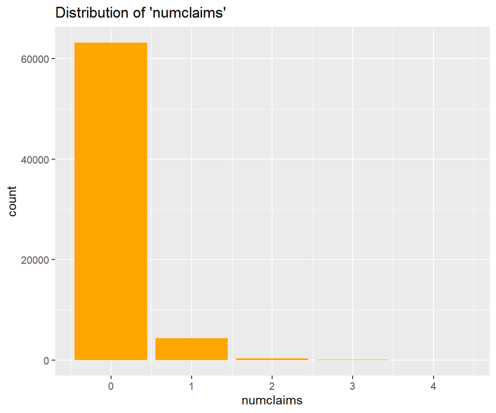

```r
# Distribution of the claim count
ggplot(dataCar, aes(x = numclaims)) +
  geom_bar(fill = "orange") +
  ggtitle("Distribution of 'numclaims'")
```

```r
fit <- glm(
  numclaims ~ veh_value + veh_body + veh_age + gender + area + agecat,
  data = dataCar,
  family = poisson(link = "log")
)
summary(fit)
```

```
##
## Call:
## glm(formula = numclaims ~ veh_value + veh_body + veh_age + gender +
##     area + agecat, family = poisson(link = "log"), data = dataCar)
##
## Deviance Residuals:
##     Min       1Q   Median       3Q      Max
## -0.7846  -0.3979  -0.3755  -0.3532   5.0000
##
## Coefficients:
##                Estimate Std. Error z value Pr(>|z|)
## (Intercept)   -1.373692   0.328875  -4.177 2.95e-05 ***
## veh_value      0.046388   0.016394   2.830 0.004660 **
## veh_bodyCONVT -2.049451   0.669159  -3.063 0.002193 **
## veh_bodyCOUPE -0.780776   0.337177  -2.316 0.020579 *
## veh_bodyHBACK -1.048694   0.318527  -3.292 0.000994 ***
## veh_bodyHDTOP -0.891602   0.327733  -2.721 0.006518 **
## veh_bodyMCARA -0.514153   0.409172  -1.257 0.208909
## veh_bodyMIBUS -1.179985   0.350059  -3.371 0.000749 ***
## veh_bodyPANVN -0.809562   0.339102  -2.387 0.016969 *
## veh_bodyRDSTR -0.793357   0.659848  -1.202 0.229235
## veh_bodySEDAN -1.010881   0.317897  -3.180 0.001473 **
## veh_bodySTNWG -1.030325   0.317876  -3.241 0.001190 **
## veh_bodyTRUCK -1.035543   0.328328  -3.154 0.001611 **
## veh_bodyUTE   -1.246375   0.322009  -3.871 0.000109 ***
## veh_age       -0.012071   0.017616  -0.685 0.493202
## genderM       -0.015962   0.030046  -0.531 0.595238
## areaB          0.062837   0.042795   1.468 0.142015
## areaC          0.008432   0.038990   0.216 0.828787
## areaD         -0.111103   0.052961  -2.098 0.035918 *
## areaE         -0.028520   0.057864  -0.493 0.622095
## areaF          0.101640   0.066141   1.537 0.124361
## agecat        -0.078076   0.010238  -7.626 2.42e-14 ***
## ---
## Signif. codes:  0 '***' 0.001 '**' 0.01 '*' 0.05 '.' 0.1 ' ' 1
##
## (Dispersion parameter for poisson family taken to be 1)
##
##     Null deviance: 26768  on 67855  degrees of freedom
## Residual deviance: 26629  on 67834  degrees of freedom
## AIC: 36108
##
## Number of Fisher Scoring iterations: 6
```

```r
# Bias on frequency scale?
mean(dataCar$numclaims) / mean(predict(fit, type = "response")) - 1
```

```
## [1] -6.350476e-14
```

**Comments**

- An increase of 1 in `veh_value` increases the log of the expected count by 0.046. On the original count scale, this is an increase of approximately 4.6%. The exact effect is $e^{0.046388}-1 = 0.047 = 4.7\%$.
- Males produce, on average, about 1.6% less claims.
- The deviance 26629 is only 0.5% smaller than the one of the null model 26768. The predictive performance of this model is thus very low: having a claim is a highly random event that cannot be predicted on individual scale.
- The predictions are unbiased on the frequency scale, a consequence of the fact that the log-link is the natural link for the Poisson model.

## 3.6 Example: logistic regression

In order to illustrate logistic regression, we will model the binary variable “claim yes=1/no=0” of the claims data by a logistic regression. Its logit link ensures that predicted probabilities are between 0 and 1 and that covariates act in a multiplicative way on the odds of having a claim.

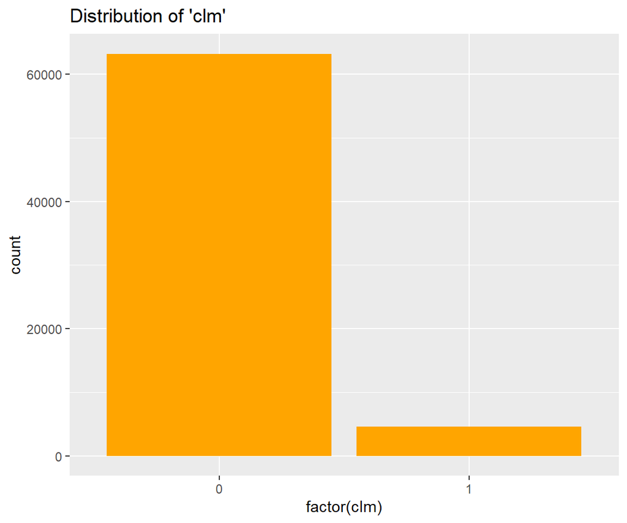

```r
library(ggplot2)
library(insuranceData)

data(dataCar)

# Distribution of the claim count
ggplot(dataCar, aes(x = factor(clm))) +
  geom_bar(fill = "orange") +
  ggtitle("Distribution of 'clm'")
```

```r
fit <- glm(
  clm ~ veh_value + veh_body + veh_age + gender + area + agecat,
  data = dataCar,
  family = binomial(link = "logit")
)
summary(fit)
```

```
##
## Call:
## glm(formula = clm ~ veh_value + veh_body + veh_age + gender +
##     area + agecat, family = binomial(link = "logit"), data = dataCar)
##
## Deviance Residuals:
##     Min       1Q   Median       3Q      Max
## -0.7716  -0.3926  -0.3697  -0.3474   2.6880
##
## Coefficients:
##               Estimate Std. Error z value Pr(>|z|)
## (Intercept)   -1.27962    0.38325  -3.339 0.000841 ***
## veh_value      0.05098    0.01787   2.853 0.004334 **
## veh_bodyCONVT -2.14392    0.70853  -3.026 0.002479 **
## veh_bodyCOUPE -0.89535    0.39235  -2.282 0.022486 *
## veh_bodyHBACK -1.13441    0.37287  -3.042 0.002347 **
## veh_bodyHDTOP -0.95742    0.38191  -2.507 0.012177 *
## veh_bodyMCARA -0.57311    0.46768  -1.225 0.220413
## veh_bodyMIBUS -1.27231    0.40312  -3.156 0.001599 **
## veh_bodyPANVN -0.92452    0.39409  -2.346 0.018978 *
## veh_bodyRDSTR -1.23888    0.82480  -1.502 0.133091
## veh_bodySEDAN -1.12596    0.37228  -3.025 0.002490 **
## veh_bodySTNWG -1.12698    0.37229  -3.027 0.002468 **
## veh_bodyTRUCK -1.15426    0.38272  -3.016 0.002562 **
## veh_bodyUTE   -1.35734    0.37622  -3.608 0.000309 ***
## veh_age       -0.01270    0.01896  -0.670 0.502834
## genderM       -0.01048    0.03218  -0.326 0.744688
## areaB          0.09862    0.04598   2.145 0.031962 *
## areaC          0.04015    0.04189   0.959 0.337794
## areaD         -0.08712    0.05653  -1.541 0.123285
## areaE         -0.01270    0.06211  -0.204 0.837982
## areaF          0.10581    0.07182   1.473 0.140658
## agecat        -0.08312    0.01097  -7.580 3.45e-14 ***
## ---
## Signif. codes:  0 '***' 0.001 '**' 0.01 '*' 0.05 '.' 0.1 ' ' 1
##
## (Dispersion parameter for binomial family taken to be 1)
##
##     Null deviance: 33767  on 67855  degrees of freedom
## Residual deviance: 33632  on 67834  degrees of freedom
## AIC: 33676
##
## Number of Fisher Scoring iterations: 5
```

**Comments**

- An increase of 1 in `veh_value` (10’000 USD) increases the log-odds of having a claim by 0.051. On the odds scale, this is an increase of approximately 5.1%. The exact calculation is $e^{0.05098}-1 = 0.052 = 5.2\%$. Thus we can say that for every additional 10’000 USD vehicle value, the odds of having a claim is increased by 5.2%.
- The odds that a male produces a claim is about 1% smaller than for females. In order words, males are 1% less likely to have a claim than females.
- The deviance 33632 is only 0.4% smaller than the one of the null model 33767.

## 3.7 Exercises

Fit a Gamma regression with log-link to explain diamond prices by `log(carat)`, `color`, `cut`, and `clarity`. Compare the coefficients with those from the corresponding linear regression with `log(price)` as response. Use dummy coding for the three categorical variables. Calculate the relative bias of the predictions on the US Dollar scale

```r
library(tidyverse)

# Turn ordered factors into unordered ones
dia <- diamonds %>%
  mutate_at(
    c("color", "cut", "clarity"),
    function(z) factor(z, ordered = FALSE)
  )
```

# 4 Chapter Summary

In this first chapter, we have introduced basic notations. Then, we have revisited multiple linear regression and some of its many aspects. To round up the chapter, we met an important generalization of linear regression, namely the generalized linear model (GLM). It includes the binary logistic regression and Poisson count regression as relevant special cases.

# 5 Chapter References

[1] A. Legendre, “Nouvelles méthodes pour la détermination des orbites des comètes”, 1805.

[2] J. A. Nelder and R. W. M. Wedderburn, “Generalized Linear Models”. Journal of the Royal Statistical Society. Series A, Vol. 135, No. 3, 1972.